# Case Study 2

## Refine model - Reduced Model

Refine Logistic Regression Model by removing not statistically significant variables (p-value >0.05) to reduce AIC value.

```r
## Model 2

model2 <- glm(Attrition ~ Age + BusinessTravel + DistanceFromHome + EnvironmentSatisfaction +   JobInvolvement + JobRole + JobSatisfaction + MaritalStatus + NumCompaniesWorked + OverTime +   RelationshipSatisfaction + TrainingTimesLastYear + WorkLifeBalance + YearsAtCompany + YearsInCurrentRole + YearsSinceLastPromotion + YearsWithCurrManager, family = 'binomial', data = train)

pander(model2)
```

Fitting generalized (binomial/logit) linear model: Attrition ~ Age + BusinessTravel + DistanceFromHome + EnvironmentSatisfaction + JobInvolvement + JobRole + JobSatisfaction + MaritalStatus + NumCompaniesWorked + OverTime + RelationshipSatisfaction + TrainingTimesLastYear + WorkLifeBalance + YearsAtCompany + YearsInCurrentRole + YearsSinceLastPromotion + YearsWithCurrManager

|  | Estimate | Std. Error | z value | Pr(>\|z\|) |
| --- | --- | --- | --- | --- |
| **(Intercept)** | 0.4845 | 0.9487 | 0.5107 | 0.6096 |
| **Age** | -0.04915 | 0.01252 | -3.926 | 8.627e-05 |
| **BusinessTravelTravel_Rarely** | 1.97 | 0.4478 | 4.399 | 1.088e-05 |
| **BusinessTravelTravel_Frequently** | 1.158 | 0.4146 | 2.793 | 0.005217 |
| **DistanceFromHome** | 0.05029 | 0.01122 | 4.482 | 7.381e-06 |
| **EnvironmentSatisfaction2** | -1.136 | 0.2928 | -3.879 | 0.0001048 |
| **EnvironmentSatisfaction3** | -1.046 | 0.2576 | -4.061 | 4.889e-05 |
| **EnvironmentSatisfaction4** | -1.301 | 0.2647 | -4.914 | 8.92e-07 |
| **JobInvolvement2** | -1.095 | 0.3759 | -2.914 | 0.003567 |
| **JobInvolvement3** | -1.28 | 0.3497 | -3.658 | 0.0002537 |
| **JobInvolvement4** | -2.009 | 0.4867 | -4.128 | 3.665e-05 |
| **JobRoleHuman Resources** | 1.871 | 0.5834 | 3.208 | 0.001338 |
| **JobRoleLaboratory Technician** | 1.712 | 0.4486 | 3.816 | 0.0001356 |
| **JobRoleManager** | 0.15 | 0.6702 | 0.2238 | 0.8229 |
| **JobRoleManufacturing Director** | 0.2321 | 0.5533 | 0.4194 | 0.6749 |
| **JobRoleResearch Director** | -0.8238 | 0.8721 | -0.9445 | 0.3449 |
| **JobRoleResearch Scientist** | 0.7388 | 0.4541 | 1.627 | 0.1038 |
| **JobRoleSales Executive** | 1.275 | 0.4418 | 2.887 | 0.003894 |
| **JobRoleSales Representative** | 2.377 | 0.5223 | 4.551 | 5.334e-06 |
| **JobSatisfaction2** | -0.5114 | 0.2854 | -1.792 | 0.07313 |
| **JobSatisfaction3** | -0.675 | 0.2534 | -2.663 | 0.007734 |
| **JobSatisfaction4** | -1.345 | 0.2744 | -4.902 | 9.488e-07 |
| **MaritalStatusMarried** | 0.4699 | 0.2774 | 1.694 | 0.09024 |
| **MaritalStatusSingle** | 1.518 | 0.2866 | 5.295 | 1.191e-07 |
| **NumCompaniesWorked** | 0.156 | 0.03903 | 3.996 | 6.434e-05 |
| **OverTimeYes** | 2.022 | 0.2041 | 9.907 | 3.865e-23 |
| **RelationshipSatisfaction2** | -0.9077 | 0.3025 | -3.001 | 0.00269 |
| **RelationshipSatisfaction3** | -0.7546 | 0.2632 | -2.867 | 0.004142 |
| **RelationshipSatisfaction4** | -0.8598 | 0.2676 | -3.213 | 0.001314 |
| **TrainingTimesLastYear** | -0.2477 | 0.07848 | -3.156 | 0.0016 |
| **WorkLifeBalance2** | -0.6561 | 0.3973 | -1.651 | 0.0987 |
| **WorkLifeBalance3** | -1.18 | 0.3737 | -3.157 | 0.001593 |
| **WorkLifeBalance4** | -0.627 | 0.4467 | -1.404 | 0.1604 |
| **YearsAtCompany** | 0.03607 | 0.03675 | 0.9813 | 0.3264 |
| **YearsInCurrentRole** | -0.12 | 0.04793 | -2.504 | 0.01228 |
| **YearsSinceLastPromotion** | 0.1928 | 0.04429 | 4.354 | 1.336e-05 |
| **YearsWithCurrManager** | -0.1411 | 0.04864 | -2.9 | 0.003726 |

```r
#run anova on model2

pander(anova(model2, test = 'Chisq'))
```

Analysis of Deviance Table

|  | Df | Deviance | Resid. Df | Resid. Dev | Pr(>Chi) |
| --- | --- | --- | --- | --- | --- |
| **NULL** | NA | NA | 1322 | 1158 | NA |
| **Age** | 1 | 32.95 | 1321 | 1125 | 9.464e-09 |
| **BusinessTravel** | 2 | 18.81 | 1319 | 1106 | 8.221e-05 |
| **DistanceFromHome** | 1 | 10.98 | 1318 | 1095 | 0.0009187 |
| **EnvironmentSatisfaction** | 3 | 21.53 | 1315 | 1074 | 8.162e-05 |
| **JobInvolvement** | 3 | 19.21 | 1312 | 1054 | 0.0002468 |
| **JobRole** | 8 | 49.79 | 1304 | 1005 | 4.494e-08 |
| **JobSatisfaction** | 3 | 19.18 | 1301 | 985.3 | 0.0002512 |
| **MaritalStatus** | 2 | 28.59 | 1299 | 956.7 | 6.202e-07 |
| **NumCompaniesWorked** | 1 | 15.34 | 1298 | 941.4 | 8.977e-05 |
| **OverTime** | 1 | 107.1 | 1297 | 834.3 | 4.292e-25 |
| **RelationshipSatisfaction** | 3 | 10.16 | 1294 | 824.2 | 0.01722 |
| **TrainingTimesLastYear** | 1 | 10.26 | 1293 | 813.9 | 0.001362 |
| **WorkLifeBalance** | 3 | 13.88 | 1290 | 800 | 0.003068 |
| **YearsAtCompany** | 1 | 1.466 | 1289 | 798.6 | 0.226 |
| **YearsInCurrentRole** | 1 | 5.519 | 1288 | 793 | 0.01881 |
| **YearsSinceLastPromotion** | 1 | 17.65 | 1287 | 775.4 | 2.658e-05 |
| **YearsWithCurrManager** | 1 | 8.282 | 1286 | 767.1 | 0.004004 |

```r
cat(model2$aic)
```

841.1039

## Evaluate top 3 parameters

Evaluate Logistic Regression Model with top 3 statisticaly significant variables (p-value <0.05)

```r
# Model 3 - Logistic Regression Model with the top 3 statistially significant parameters

model3 <- glm(Attrition ~ JobSatisfaction + MaritalStatus + OverTime , family = 'binomial', data = train)

cat(model3$aic)
```

1030.523

## Reduced Model Evaluation

```r
#Prediction for the test data

predmodel <- round(predict(model2,test,type='response'),digits=0)
comparison <- data.frame(predmodel,test$Attrition,test$EmployeeNumber)
names(comparison)<- c("Predicted","Actual","EmployeeNumber")
pred <- ifelse(predmodel>0.5,2,1)

#Loading required libraries
library(ROCR)
library(Metrics)
library(pROC)
```

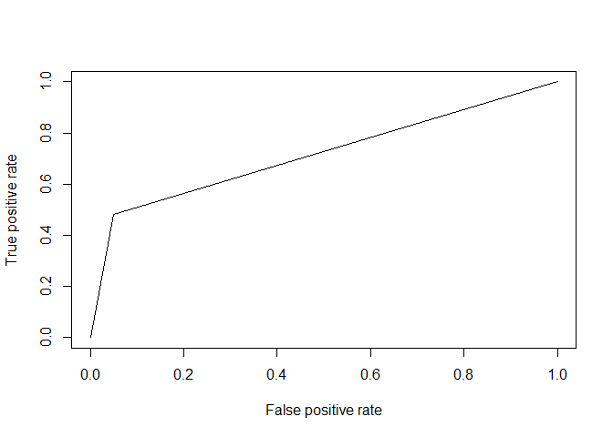

```r
pr <- prediction(pred,test$Attrition)
perf <- performance(pr,measure = "tpr",x.measure = "fpr")
plot(perf)
```

```r
auc(test$Attrition,pred)
```

Area under the curve: 0.7157

## Prediction probabilities and results in comparison with actuals

```r
#Prediction probabilities and results in comparison with actuals

comparison2 <- cbind(predmodel,pred,test$Attrition,test$EmployeeNumber)
colnames(comparison2) <- c("Probability Greater Than .5 is Yes and Lower than .5 is No ", "Prediction - 2 Yes and 1 is No","Actual - 2 Yes and 1 is No","Employee Number")

#Missclassification error
tabb <- table(Predicted = pred, Actual = test$Attrition)
row.names(tabb) <- c("total number","total missclassifications")
knitr::kable(head(tabb))
```

|  | No | Yes |
| --- | --- | --- |
| total number | 114 | 14 |
| total missclassifications | 6 | 13 |

```r
#Missclassification percentage
cat(1-sum(diag(tabb))/sum(tabb))
```

0.1360544

```r
#Goodness of fit test

cat(with(model2,pchisq(null.deviance-deviance,df.null-df.residual,lower.tail = F)))
```

3.959023e-61

# Data Analysis and Discussion

After cleaning up the file, the variables were characterized as ether numbers or parameters with levels. The levels were then transformed to numbers to find correlations with the Attrition. Once those correlations were calculated, the correlation coefficients were sorted from highest to lowest. The top 3 parameters with the highest positive correlation coefficients were:

1. Overtime
2. Marital Status
3. Distance from Home

Since two of these variables were factors converted to numbers a visual evaluation was recommended. Also, it was important to consider the absolute values of the correlations. Since several variables were factors. When studying the correlation bar graphs, there is a clear correlation between the first two parameters, over time and marital status with attrition, whereas the distance from home is not as evident. Regarding the usefulness of this information, the company can probably address overtime. Marital status and distance from home are a little more difficult. When evaluating the absolute value of the correlations, the top three parameters are:

1. Overtime
2. Total working years
3. Job Level

The first parameter (overtime) presents itself as an overwhelming factor as for the second and third the models disagree. Job satisfaction is definitively an important parameter and if an employee satisfaction level is low the employee is more likely to leave than otherwise. However, the number of employees that leave and report low job satisfaction is significantly lower than the single employees. That said, the company can address employee satisfaction but can do little about the employee marital status. The regression model is intended to help identify areas of improvement and way to lower attrition rates.

# Conclusion

The data science team identified

1. Overtime
2. Total working years
3. Job Level

As the top three factor that lead to turnover.And observed that the Sales Representative were the most sensitive Job Role to attrition affected with factors such as total working years, job level and age.

Ref.: https://www.hackerearth.com/practice/machine-learning/machine-learning-algorithms/logistic-regression-analysis-r/tutorial/